# QUD Adult

Hugh Rabagliati

5 November 2014

Working Directory should be “AdultExperiment”.

*Action data*

We read in action data from a single Excel spreadsheet, and then graph it and analyze it.

1. Read in the data

[output not shown]

2. Graph the data

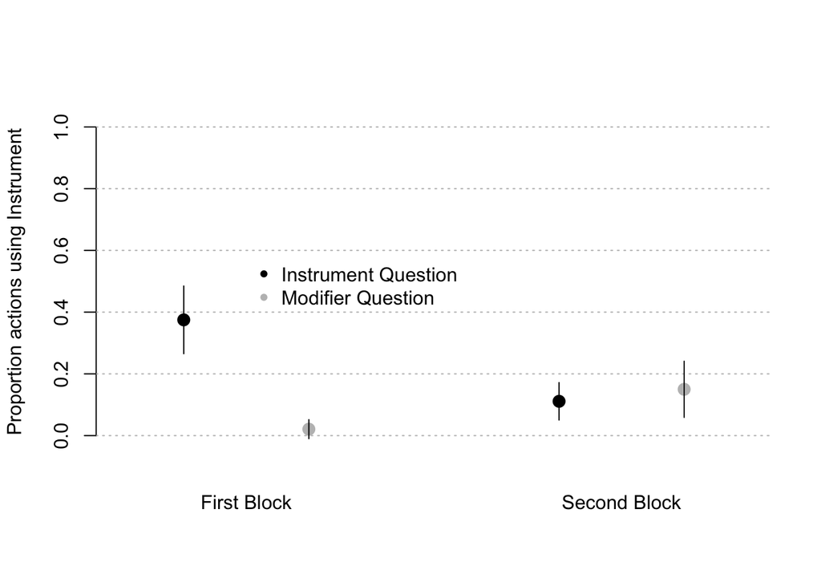

```r
q <- summaryBy(Inst~Condition+Block+SubjNo, data = QUD.Act, FUN = c(mean,sd))
q <- summaryBy(Inst.mean~Condition+Block, data = q, FUN = c(mean,sd))
q$SE = q$Inst.mean.sd/sqrt(12)
tapply(q$Inst.mean.mean, list(q$Block, q$Condition), FUN = mean) -> o
tapply(q$SE, list(q$Block,q$Condition), FUN = mean) -> se

 barplot(o, beside =T , ylim = c(-0.1,1.1),col = "white",  border = NA, ylab = "Proportion actions using Instrument", names.arg = c("First Block", "Second Block"))
 legend(2.,0.6, legend = c("Instrument Question", "Modifier Question"), bty = "n", col = c("black","grey"), pch = 20)
 points(c(1.5,4.5), o[,1], pch = 20, cex = 2, col = "black")
 points(c(2.5,5.5), o[,2], pch = 20, cex = 2, col = "grey")
 grid(nx = NA, ny = NULL, col = "gray", lty = "dotted",lwd = par("lwd"), equilogs = TRUE)
  arrows(c(1.5,4.5,2.5,5.5), (c(o) + c(se)+0.01), c(1.5,4.5,2.5,5.5), (c(o) - c(se)-0.01), code = 0)
```

3. Analyze the data

```r
summary(glmer(Inst~Condition*Block + (1+Condition|SubjNo) + (1+Condition|ItemNo), data = QUD.Act, family = "binomial"))
```

```
## Generalized linear mixed model fit by maximum likelihood (Laplace
##   Approximation) [glmerMod]
##  Family: binomial  ( logit )
## Formula:
## Inst ~ Condition * Block + (1 + Condition | SubjNo) + (1 + Condition |
##     ItemNo)
##    Data: QUD.Act
##
##      AIC      BIC   logLik deviance df.resid
##    154.7    187.3    -67.4    134.7      182
##
## Scaled residuals:
##    Min     1Q Median     3Q    Max
## -1.454 -0.359 -0.222 -0.057  3.947
##
## Random effects:
##  Groups Name         Variance Std.Dev. Corr
##  SubjNo (Intercept)  2.83e+00 1.68136
##         ConditionMod 1.07e-01 0.32659  1.00
##  ItemNo (Intercept)  8.44e-05 0.00919
##         ConditionMod 3.04e-04 0.01745  -0.20
## Number of obs: 192, groups:  SubjNo, 24; ItemNo, 8
##
## Fixed effects:
##                          Estimate Std. Error z value Pr(>|z|)
## (Intercept)                -2.767      0.637   -4.34  1.4e-05 ***
## ConditionMod               -1.094      0.530   -2.06    0.039 *
## BlockSecond                 0.180      0.360    0.50    0.618
## ConditionMod:BlockSecond    1.112      0.494    2.25    0.024 *
## ---
## Signif. codes:  0 '***' 0.001 '**' 0.01 '*' 0.05 '.' 0.1 ' ' 1
##
## Correlation of Fixed Effects:
##             (Intr) CndtnM BlckSc
## ConditionMd  0.654
## BlockSecond -0.369 -0.588
## CndtnMd:BlS -0.383 -0.289  0.521
```

```r
summary(glmer(Inst~Condition + (1+Condition|SubjNo) + (1+Condition|ItemNo), data = QUD.Act[QUD.Act$Block == "First",], family = "binomial"))
```

```
## Generalized linear mixed model fit by maximum likelihood (Laplace
##   Approximation) [glmerMod]
##  Family: binomial  ( logit )
## Formula: Inst ~ Condition + (1 + Condition | SubjNo) + (1 + Condition |
##     ItemNo)
##    Data: QUD.Act[QUD.Act$Block == "First", ]
##
##      AIC      BIC   logLik deviance df.resid
##     81.1    101.6    -32.6     65.1       88
##
## Scaled residuals:
##    Min     1Q Median     3Q    Max
##  -1.23  -0.38   0.00   0.00   1.66
##
## Random effects:
##  Groups Name         Variance Std.Dev. Corr
##  SubjNo (Intercept)   91.0     9.54
##         ConditionMod  65.4     8.09    1.00
##  ItemNo (Intercept)  171.4    13.09
##         ConditionMod 163.9    12.80    1.00
## Number of obs: 96, groups:  SubjNo, 24; ItemNo, 8
##
## Fixed effects:
##               Estimate Std. Error z value Pr(>|z|)
## (Intercept)  -21.70544    0.00151  -14417   <2e-16 ***
## ConditionMod -20.93207    0.00151  -13863   <2e-16 ***
## ---
## Signif. codes:  0 '***' 0.001 '**' 0.01 '*' 0.05 '.' 0.1 ' ' 1
##
## Correlation of Fixed Effects:
##             (Intr)
## ConditionMd -0.003
```

```r
summary(glmer(Inst~Condition + (1+Condition|SubjNo) + (1+Condition|ItemNo), data = QUD.Act[QUD.Act$Block == "Second",], family = "binomial"))
```

```
## Generalized linear mixed model fit by maximum likelihood (Laplace
##   Approximation) [glmerMod]
##  Family: binomial  ( logit )
## Formula: Inst ~ Condition + (1 + Condition | SubjNo) + (1 + Condition |
##     ItemNo)
##    Data: QUD.Act[QUD.Act$Block == "Second", ]
##
##      AIC      BIC   logLik deviance df.resid
##     88.3    108.8    -36.1     72.3       88
##
## Scaled residuals:
##    Min     1Q Median     3Q    Max
## -0.796 -0.315 -0.313 -0.170  2.799
##
## Random effects:
##  Groups Name         Variance Std.Dev. Corr
##  SubjNo (Intercept)  2.16e+00 1.47071
##         ConditionMod 7.62e-01 0.87282  1.00
##  ItemNo (Intercept)  0.00e+00 0.00000
##         ConditionMod 2.96e-06 0.00172   NaN
## Number of obs: 96, groups:  SubjNo, 24; ItemNo, 8
##
## Fixed effects:
##              Estimate Std. Error z value Pr(>|z|)
## (Intercept)    -2.554      0.793   -3.22   0.0013 **
## ConditionMod   -0.372      0.830   -0.45   0.6541
## ---
## Signif. codes:  0 '***' 0.001 '**' 0.01 '*' 0.05 '.' 0.1 ' ' 1
##
## Correlation of Fixed Effects:
##             (Intr)
## ConditionMd 0.608
```

*Eye tracking graphs and analysis*

To process the data for analysis (take in the Excel files, expand them over timepoints), we need to load in the scripts in the proc_subj.r, ET_Import.r and Graphing.r files. Once that’s done, we run the first set of code in QUD_Summary, which produces the dataframe QUD_Expand. That can also be loaded up, as below.

```r
load("QUD_Expand_Adult.RDATA")
```

We’ll need to import some libraries for plotting etc.

And now construct and then melt the dataframes that we use for plotting

```r
se <- function(x){
  x <- sd(x)/sqrt(12)
    return(x)
    }

QUD.Graph <- summaryBy(Inst+TA+DA+DI~TimeFrame+Cond+Name, data = QUD.Expand[QUD.Expand$TimeFrame > -300 & QUD.Expand$TimeFrame <=1500,], FUN = c(mean),keep.names = T)
QUD.Graph <- summaryBy(Inst+TA+DA+DI~TimeFrame+Cond, data = QUD.Graph, FUN = c(mean,se))
levels(QUD.Graph$Cond)[levels(QUD.Graph$Cond)=="Inst"] <- "Instrument Question"
levels(QUD.Graph$Cond)[levels(QUD.Graph$Cond)=="Mod"] <- "Modifier Question"

QUD.Graph2 <- melt(QUD.Graph,
        # ID variables - all the variables to keep but not split apart on
    id.vars=c("TimeFrame","Cond"),
        # The source columns
    measure.vars=c("Inst.mean","TA.mean", "DA.mean", "DI.mean" ),
        # Name of the destination column that will identify the original
        # column that the measurement came from
    value.name="Prop",
    variable.name ="Quadrant"
    )
QUD.Graph2$Quadrant <- revalue(QUD.Graph2$Quadrant, c("Inst.mean"="Target Instrument", "TA.mean"="Target Animal", "DA.mean" = "Distractor Animal","DI.mean" = "Distractor Instrument"))

QUD.Graph2$Quadrant <- ordered(QUD.Graph2$Quadrant, levels = c("Target Animal", "Distractor Animal", "Target Instrument", "Distractor Instrument"))
```

And then plot our graphs. The first graph plots mean prop of trials looking at the instrument over the time.

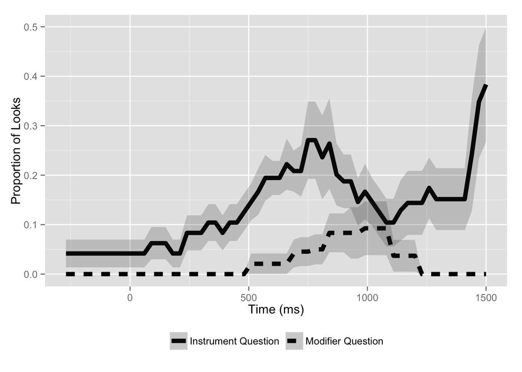

```r
ggplot(QUD.Graph,aes(TimeFrame,Inst.mean,linetype = Cond)) + stat_summary(fun.y = mean, geom = "line", size = 2) + geom_ribbon(aes(ymin=(Inst.mean - Inst.se), ymax=(Inst.mean + Inst.se)), alpha=0.2)+ theme(legend.title=element_blank(),legend.position="bottom")+labs(x = "Time (ms)",y = "Proportion of Looks")
```

The second plot is a standard spaghetti plot, showing looks to each different quadrant.

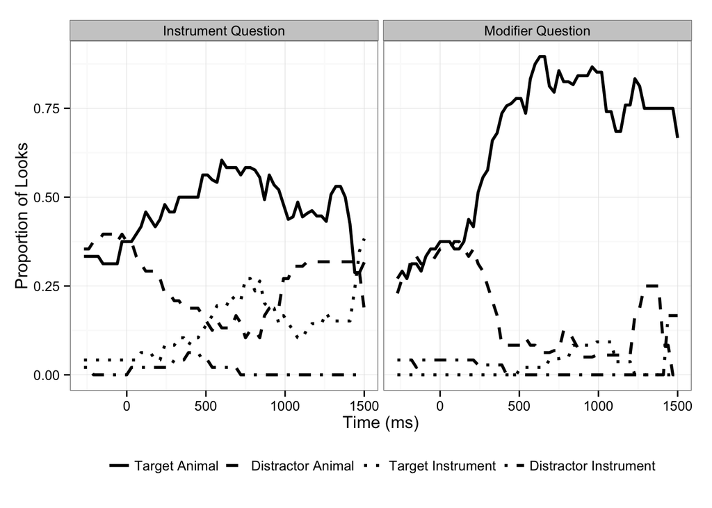

```r
ggplot(QUD.Graph2,aes(TimeFrame,Prop,linetype = Quadrant)) + facet_wrap(~Cond, nrow = 1, ncol = 2) + stat_summary(fun.y = mean, geom = "line", size = 1) + theme(legend.title=element_blank(),legend.position="bottom")+ theme_bw()+theme(legend.title=element_blank(),legend.position="bottom",legend.key = element_rect(linetype=0))+scale_linetype_manual(values=c(1,2,3,4))+labs(x = "Time (ms)",y = "Proportion of Looks")
```

To *analyze* this data, we split it into two 500ms time windows, beginning 200 and 700ms after the onset of the target word.

```r
QUD.Expand$Window <- as.factor(ifelse(QUD.Expand$TimeFrame <700, "EarlyWindow","LateWindow"))
QUD.Window <- summaryBy(Inst~Cond+Trial+Name+Window, data = QUD.Expand[QUD.Expand$TimeFrame > 200 & QUD.Expand$TimeFrame < 1200,], FUN = c(mean),keep.names = T,na.rm = T)
QUD.Window$Inst <- ifelse(QUD.Window$Inst > 0,1,0)
contrasts(QUD.Window$Cond)[1] <- -1
summaryBy(Inst~Age+Window+Cond+QCond, data = QUD.Window)
```

```
##        Window Cond Inst.mean
## 1 EarlyWindow Inst   0.27083
## 2 EarlyWindow  Mod   0.04167
## 3  LateWindow Inst   0.31111
## 4  LateWindow  Mod   0.08333
```

We plot a graph

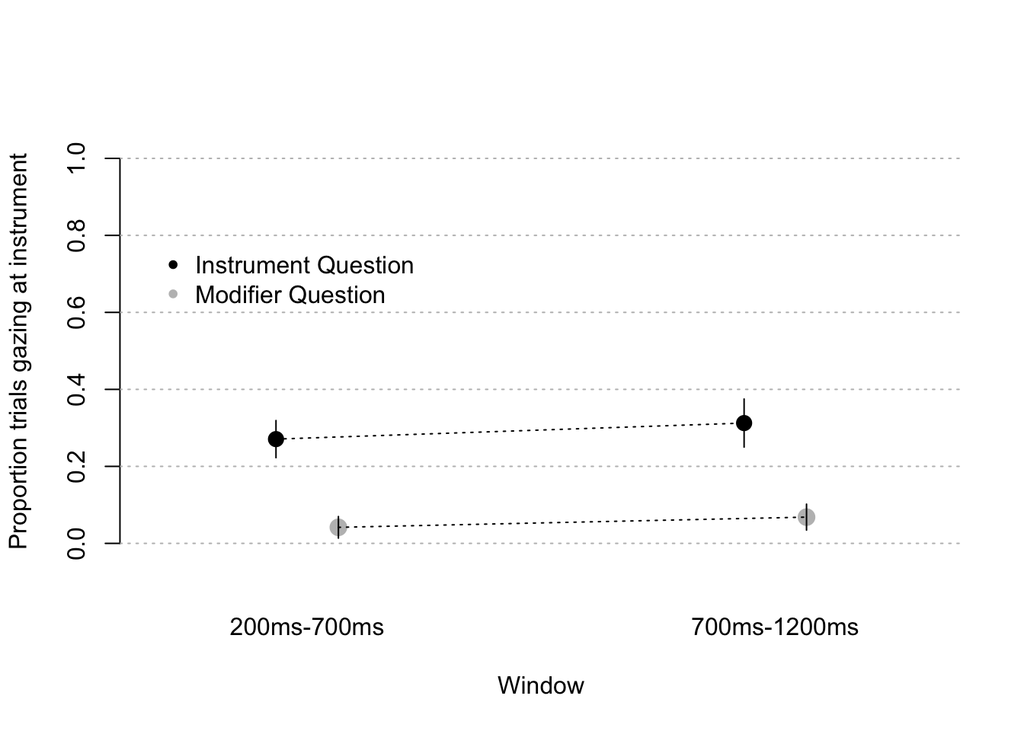

```r
q <- summaryBy(Inst~Cond+Window+Name, data = QUD.Window, FUN = c(mean,sd))
q <- summaryBy(Inst.mean~Cond+Window, data = q, FUN = c(mean,sd))
q$SE = q$Inst.mean.sd/sqrt(12)
tapply(q$Inst.mean.mean, list(q$Window, q$Cond), FUN = mean) -> o
tapply(q$SE, list(q$Window,q$Cond), FUN = mean) -> se

 barplot(o, beside =T , ylim = c(-0.1,1.1),col = "white",  border = NA, ylab = "Proportion trials gazing at instrument", xlab = "Window",names.arg = c("200ms-700ms", "700ms-1200ms"))
 legend(1,0.8, legend = c("Instrument Question", "Modifier Question"), bty = "n", col = c("black","grey"), pch = 20)
 points(c(1.8,4.8), o[,1], pch = 20, cex = 2, col = "black")
 points(c(2.2,5.2), o[,2], pch = 20, cex = 2, col = "grey",lwd = 2)
 grid(nx = NA, ny = NULL, col = "gray", lty = "dotted",lwd = par("lwd"), equilogs = TRUE)
  arrows(c(1.8,4.8,2.2,5.2), (c(o) + c(se)), c(1.8,4.8,2.2,5.2), (c(o) - c(se)), code = 0)
lines(c(1.8,4.8), o[,1], pch = 15, cex = 5, col = "black", lty = 3)
lines(c(2.2,5.2), o[,2], pch = 15, cex = 5, col = "black", lty = 3)
```

We run our stats.

```r
summary(glmer(Inst~Cond*Window+ (1|Name) + (1|Trial)+(0+Cond+Window|Trial), data = QUD.Window, family = "binomial",control=glmerControl(optCtrl=list(maxfun=20000), optimizer = "bobyqa" )))
```

```
## Generalized linear mixed model fit by maximum likelihood (Laplace
##   Approximation) [glmerMod]
##  Family: binomial  ( logit )
## Formula: Inst ~ Cond * Window + (1 | Name) + (1 | Trial) + (0 + Cond +
##     Window | Trial)
##    Data: QUD.Window
## Control:
## glmerControl(optCtrl = list(maxfun = 20000), optimizer = "bobyqa")
##
##      AIC      BIC   logLik deviance df.resid
##    171.8    210.0    -73.9    147.8      165
##
## Scaled residuals:
##    Min     1Q Median     3Q    Max
## -0.763 -0.583 -0.251 -0.104  3.697
##
## Random effects:
##  Groups  Name             Variance Std.Dev. Corr
##  Name    (Intercept)      0.0750   0.274
##  Trial   (Intercept)      0.0000   0.000
##  Trial.1 CondInst         0.0219   0.148
##          CondMod          1.7937   1.339     1.00
##          WindowLateWindow 0.2616   0.511    -1.00 -1.00
## Number of obs: 177, groups:  Name, 24; Trial, 8
##
## Fixed effects:
##                          Estimate Std. Error z value Pr(>|z|)
## (Intercept)                -2.452      0.671   -3.66  0.00026 ***
## CondMod                    -1.439      0.634   -2.27  0.02316 *
## WindowLateWindow            0.666      0.620    1.07  0.28297
## CondMod:WindowLateWindow    0.490      0.604    0.81  0.41673
## ---
## Signif. codes:  0 '***' 0.001 '**' 0.01 '*' 0.05 '.' 0.1 ' ' 1
##
## Correlation of Fixed Effects:
##             (Intr) CondMd WndwLW
## CondMod      0.857
## WindwLtWndw -0.737 -0.607
## CndMd:WndLW -0.517 -0.680  0.663
```

```r
summary(glmer(Inst~Cond+ (1|Name) + (1|Trial)+(0+Cond|Trial), data = subset(QUD.Window, Window == "EarlyWindow" ), family = "binomial",control=glmerControl(optCtrl=list(maxfun=20000), optimizer = "bobyqa" )))
```

```
## Generalized linear mixed model fit by maximum likelihood (Laplace
##   Approximation) [glmerMod]
##  Family: binomial  ( logit )
## Formula: Inst ~ Cond + (1 | Name) + (1 | Trial) + (0 + Cond | Trial)
##    Data: subset(QUD.Window, Window == "EarlyWindow")
## Control:
## glmerControl(optCtrl = list(maxfun = 20000), optimizer = "bobyqa")
##
##      AIC      BIC   logLik deviance df.resid
##     86.7    104.7    -36.3     72.7       89
##
## Scaled residuals:
##    Min     1Q Median     3Q    Max
## -0.609 -0.609 -0.209 -0.209  4.796
##
## Random effects:
##  Groups  Name        Variance Std.Dev. Corr
##  Name    (Intercept) 0.00e+00 0.00e+00
##  Trial   (Intercept) 0.00e+00 0.00e+00
##  Trial.1 CondInst    0.00e+00 0.00e+00
##          CondMod     2.37e-14 1.54e-07  NaN
## Number of obs: 96, groups:  Name, 24; Trial, 8
##
## Fixed effects:
##             Estimate Std. Error z value Pr(>|z|)
## (Intercept)   -2.063      0.396   -5.21  1.9e-07 ***
## CondMod       -1.073      0.396   -2.71   0.0068 **
## ---
## Signif. codes:  0 '***' 0.001 '**' 0.01 '*' 0.05 '.' 0.1 ' ' 1
##
## Correlation of Fixed Effects:
##         (Intr)
## CondMod 0.664
```

```r
summary(glmer(Inst~Cond + (1|Name) +(1|Trial)+ (0+Cond|Trial), data = subset(QUD.Window, Window == "LateWindow" ), family = "binomial",control=glmerControl(optCtrl=list(maxfun=20000), optimizer = "bobyqa" )))
```

```
## Generalized linear mixed model fit by maximum likelihood (Laplace
##   Approximation) [glmerMod]
##  Family: binomial  ( logit )
## Formula: Inst ~ Cond + (1 | Name) + (1 | Trial) + (0 + Cond | Trial)
##    Data: subset(QUD.Window, Window == "LateWindow")
## Control:
## glmerControl(optCtrl = list(maxfun = 20000), optimizer = "bobyqa")
##
##      AIC      BIC   logLik deviance df.resid
##     90.4    107.2    -38.2     76.4       74
##
## Scaled residuals:
##    Min     1Q Median     3Q    Max
## -0.696 -0.656 -0.303 -0.271  3.304
##
## Random effects:
##  Groups  Name        Variance Std.Dev. Corr
##  Name    (Intercept) 0.0000   0.000
##  Trial   (Intercept) 0.0000   0.000
##  Trial.1 CondInst    0.0444   0.211
##          CondMod     0.1518   0.390    -1.00
## Number of obs: 81, groups:  Name, 23; Trial, 8
##
## Fixed effects:
##             Estimate Std. Error z value Pr(>|z|)
## (Intercept)   -1.634      0.412   -3.96  7.4e-05 ***
## CondMod       -0.829      0.405   -2.05    0.041 *
## ---
## Signif. codes:  0 '***' 0.001 '**' 0.01 '*' 0.05 '.' 0.1 ' ' 1
##
## Correlation of Fixed Effects:
##         (Intr)
## CondMod 0.659
```